## Lake trout abundance and mortality

A statistical catch-at-age (SCAA) model was used to estimate lake trout abundance and mortality from **`1998`** through **`2018`** Unlike in previous years, the SCAA model structure was modified so that suppression gillnetting, suppression trapnetting, and distribution gillnetting were treated as 3 distinct fisheries. In previous years, harvest from suppression trapnetting and distribution gillnetting were combined with suppression gillnet harvest for calculating total observed harvest and distribution gillnetting was treated as a survey index where fish were not harvested. The SCAA model was also modified in that distribution gillnetting was treated as a Type-1 fishery that occurred after 68% of the annual suppression gillnetting fishing mortality and natural mortality had occurred. The SCAA model was also modified so that the distribution gillnetting harvest and age composition included both fixed and random sites to account for most of the harvest that is occurring from the distribution gillnetting program.

Similar to previous years, gillnetting catchability was allowed to vary through time with random deviations for both the distribution and suppression netting programs. Because the trapnetting suppression program only lasted from 2010 to 2013, trapnet catchability was assumed to be temporally constant. For suppression gillnetting, separate catchability parameters were estimated for 1998-2000 and 2001-2018 time blocks. Fully-selected instantaneous fishing mortality (F) for suppression gillnetting increased from **`0.09`** (0.07 – 0.11; 95% CI) in 1998 to **`1.10`** (0.87 – 1.26; 95% CI) in 2017 (Figure 2). The estimate of F for suppression gillnetting in 2018 was **`1.13`** (0.85 – 1.36; 95% CI). In 2017 and 2018, suppression gillnetting effort was **`90,349`** and **`97,397`** 100-m net nights, which is the highest effort that has occurred on the lake. Abundance of age-2 and older lake trout increased from **`99,716`** (86,300 – 111,800; 95% CI) lake trout in 1998 to **`922,960`** (810,140 – 1,038,780; 95% CI) fish in 2012 (Figure 3). Estimated abundance was **`628,203`** (494,240 – 766,900; 95% CI) lake trout at the beginning of 2018. By the end of 2018, abundance had been reduced to **`240,250`** (161,800 – 320,300; 95% CI) fish. Approximately **`53`**% of the 2018 lake trout abundance at the start of the year was composed of age-2 (i.e., new recruits) fish. Approximately **`98`**% of the lake trout abundance at the start of year was composed of fish age-5 and younger. With respect to population biomass, age-2 and older biomass, which increased from **`46831`** (37,200 – 54,700; 95% CI) kg in 1998 to **`426937`** (358,700 – 472,600; 95% CI) kg in 2012, declined to **`232000`** (182,400 – 279,500; 95% CI) kg at the start of 2018 (Figure 4). The 33% decline in lake trout biomass from 2012 through 2017 was caused by a reduction in the abundance of adult lake trout, as weight at age of lake trout was fairly consistent during these time periods. By the end of 2018, biomass had declined to 74,600 (48,800 – 100,300) kg.

Abundance estimates from the SCAA model were converted to estimates of annual fecundity, which were used as a measure of spawning stock biomass for fitting a stock-recruitment relationship. In previous years, only data as far back as the 2006 year class was used in fitting a stock recruitment relationship but the reasoning behind this was not clear. For this year’s evaluation, data back to the **`1998`** year class was used in fitting the stock recruitment relationship (Figure 5). A Ricker stock-recruitment function was to the stock-recruit data. Based on the fitted relationship, the Yellowstone lake trout population has been on the ascending limb of the stock-recruit curve for the **`1998`** to **`2016`** year classes (Figure 6). Variation in the stock recruit data is fairly large (Figure 6). Given the recruit estimates for the 2012 to 2016 year classes are consistently above the fitted relationship, the observed data is suggestive that early life survival of lake trout has been higher in recent years than it was in the early to mid 2000s.

In last year’s assessment, it was noted that the assessment model and simulation results were sensitive to assumptions about the assumed shape of the selectivity curve, which describes the relative vulnerability of different ages of lake trout to suppression gillnets. In particular, if it was assumed that the selectivity function was dome-shaped (gamma function), the length of time needed to achieve suppression targets was longer than when the selectivity function was assumed to be asymptotic (logistic function). The changes that were made to the SCAA model for this year’s assessment and correction of some of the input data used in fitting the SCAA model reduced the sensitivity of the assessment and simulation model result to the shape of the selectivity curve. Model comparison indices suggest that an asymptotic selectivity function provided the best model fit to the observed data.

## Figures

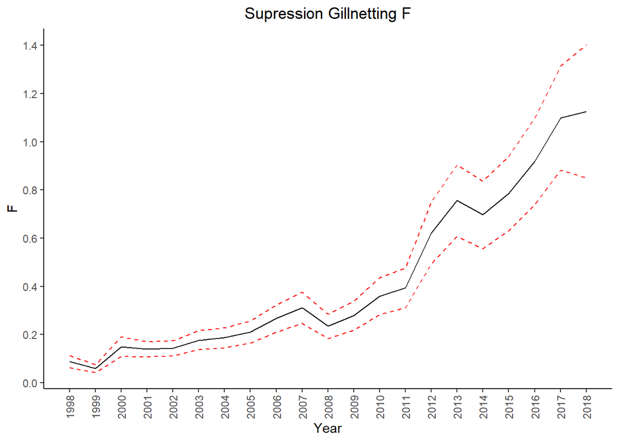

Figure 2. Estimates of fully selected instantaneous fishing mortality (F) for suppression gillnetting for Yellowstone Lake lake trout from **`1998`** through **`2018`** using a statistical catch-at-age model. Dashed lines delineate 95% confidence intervals.

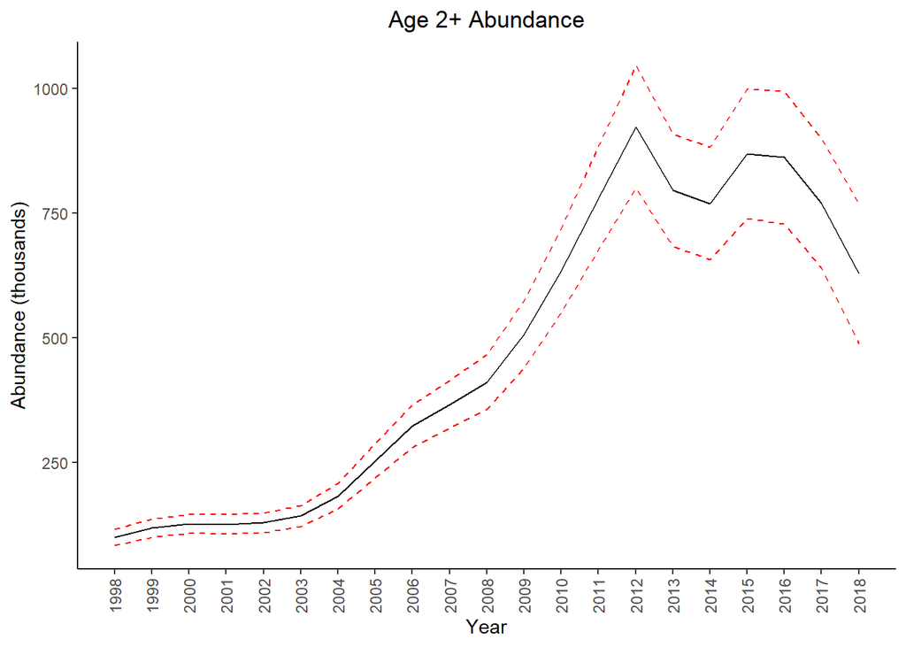

Figure 3. Abundance estimates for age-2 and older lake trout at the start of the year for **`1998`** to **`2018`** using a statistical catch-at-age model. Dashed lines delineate 95% confidence intervals.

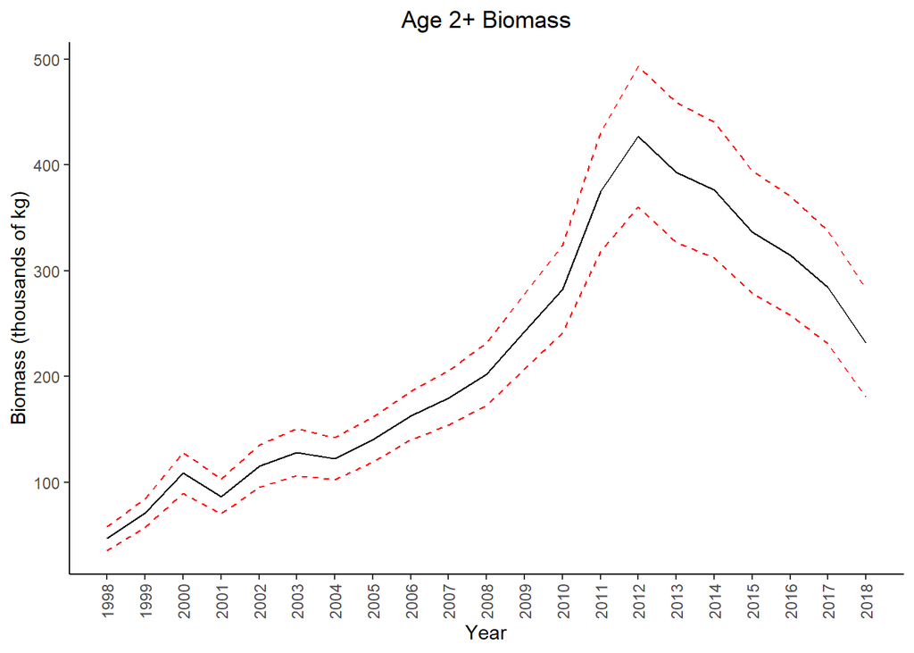

Figure 4. Biomass estimates for age-2 and greater lake trout from **`1998`** through **`2018`** using a statistical catch-at-age model. Dashed lines delineate 95% confidence intervals.

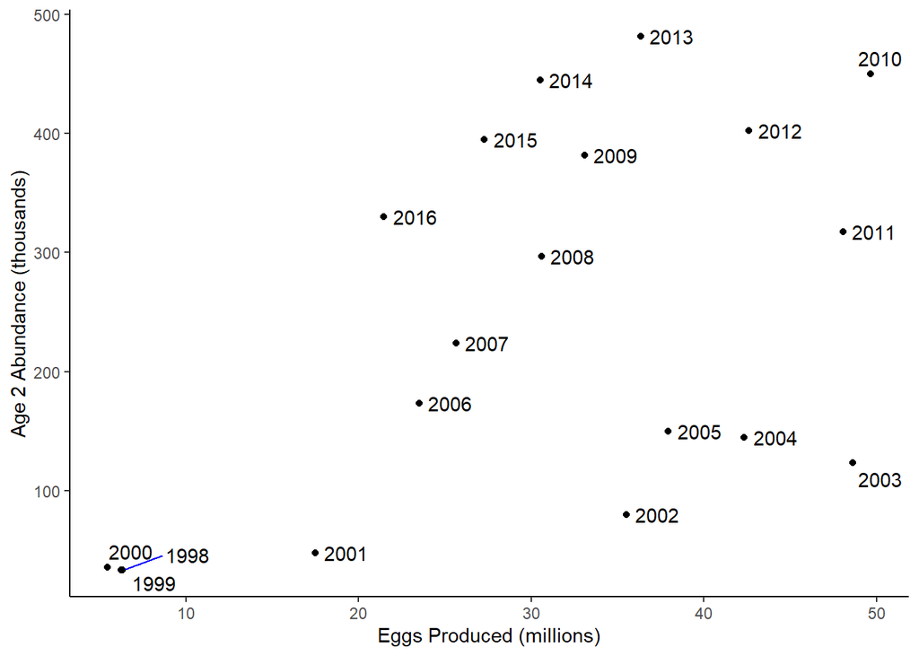

Figure 5. Age-2 lake trout abundance in relation to egg abundance, lagged by 2 years. Labels indicate year class. The 1998, 1999, and 2000 year classes overlay one another in the bottom left corner of the graph.

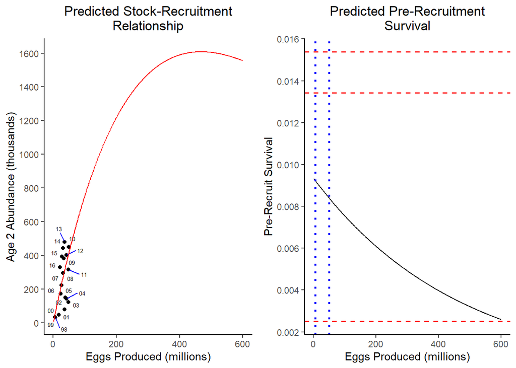